# Can you predict stock price movements using neural networks

## a project by Alexander Michalik, Lukas Schneider, Sebastian Bielfeldt and Jesse Jones

- Objective
- Data Preparation
  - One-Hot Encoding
- Evaluation Functions
- Neural Network Models
  - Convolutional Neural Network
    - Convolutional Neural Network with OHE Industry Sector Input
  - Fully Connected Neural Network
  - Recurrent Neural Network with LSTM
    - Recurrent Neural Network with LSTM and OHE Industry Sector Input
  - Recurrent Neural Network with GRU
    - Recurrent Neural Network with GRU and OHE Industry Sector Input
- Discussion and Outlook

## Objective

- Predict seemingly random Stock Market Changes
- Try to find Underlying Patterns
- Evaluate Time Series as Prediction Factor
- Use known effect of Industry Correlation for Prediction

## Data

```python
def get_data_subsets(df, dur, variant, onehot):
    """
    variant options: month, vola, next_day
    """

    branches_ = pd.read_csv('snp500info.csv', index_col=0)
    branches = branches_.drop(columns = ['Security', 'GICS Sub Industry', 'start at yahoo'])

    companies = list(df)
    data_onehot = branches.loc[branches.index.isin(companies)].iloc[:,0]
    # integer encode
    label_encoder = LabelEncoder()
    integer_encoded = label_encoder.fit_transform(data_onehot)
    # binary encode
    onehot_encoder = OneHotEncoder(sparse=False)
    integer_encoded = integer_encoded.reshape(len(integer_encoded), 1)
    onehot_encoded = onehot_encoder.fit_transform(integer_encoded).T

    df = np.array(df)
    month = 30
    leng = df.shape[0]
    x=[]
    y=[]
    for i in range(leng):
        if dur+i>=leng:
            break
        if onehot:
            x_inp = np.concatenate((onehot_encoded, df[i:dur+i,:]))
        else:
            x_inp = df[i:dur+i,:]

        if variant == 'vola':
            x.append(np.abs(x_inp))
            y.append(np.abs(df[dur+i,:]))
        else:
            x.append(x_inp)
            if variant == 'month':
                y.append(np.mean(df[dur+i:dur+i+month,:], axis = 0))
            elif variant == 'next_day':
                y.append(df[dur+i,:])
            else:
                raise NameError("Use correct fun_label")
    return np.array(x),np.array(y)
```

### Convolutional Neural Network

#### advantages:

- recognizes short-term patterns
- less susceptible to overfitting

#### disadvantages:

```python
model_cnn,x_train,y_train,x_test,y_test = main_cnn(returns, 100, 2000, variant='month')
print(model_cnn.summary())
```

```
x-train shape: (1900, 100, 20)
y-train shape: (1900, 20)
x-test shape: (518, 100, 20)
y-test shape: (518, 20)
test shape: (618, 20)
8.954179948925658e-06
8.954179975262377e-06
0.0022624812554568052
Model: "sequential_5"
_________________________________________________________________
Layer (type)                 Output Shape              Param #
=================================================================
conv1d_5 (Conv1D)            (None, 98, 64)            3904
_________________________________________________________________
conv1d_6 (Conv1D)            (None, 96, 64)            12352
_________________________________________________________________
dropout_7 (Dropout)          (None, 96, 64)            0
_________________________________________________________________
max_pooling1d_3 (MaxPooling1 (None, 48, 64)            0
_________________________________________________________________
flatten_6 (Flatten)          (None, 3072)              0
_________________________________________________________________
dense_18 (Dense)             (None, 100)               307300
_________________________________________________________________
dense_19 (Dense)             (None, 20)                2020
=================================================================
Total params: 325,576
Trainable params: 325,576
Non-trainable params: 0
_________________________________________________________________
None
```

```
percentage of correctly predicted directions of returns: 0.5414092664092663
Difference between mean return and return of calculated top 5: 0.0005194000399918203
(518, 20)
```

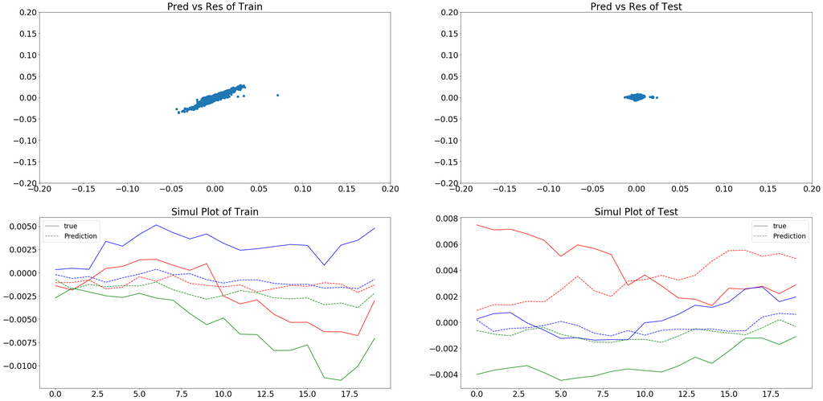

```python
directional_goodness(model_cnn, x_test, y_test)
compare_top(model_cnn, x_test, y_test)
plots(model_cnn, x_test=x_test, x_train=x_train, y_test=y_test, y_train=y_train)
```

Expectations:

- CNN learns patterns in stock market changes, if there are any recognisable patterns
- Patterns lead to better predictions

Results:

- No Patterns were recognised, or influence of recognised patterns was diminishing/not contributing to better predictions

### One-Hot Encoded Branch Info Convolutional Neural Network

#### advantages:

- network should have easier job learning known correlations inside industries

#### disadvantages:

```python
model_cnn_2inputs,x_train,y_train,x_test,y_test = main_cnn_2inputs(returns, 100, 2000, variant='month')
print(model_cnn_2inputs.summary())
```

```
x-train shape: (1900, 100, 20)(1900, 7, 20)
y-train shape: (1900, 20)
x-test shape: (518, 100, 20)(518, 7, 20)
y-test shape: (518, 20)
test shape: (618, 20)
9.612857262170415e-06
9.612856956664473e-06
0.0023594193626195192
Model: "model_9"
__________________________________________________________________________________________________
Layer (type)                    Output Shape         Param #     Connected to
==================================================================================================
input_5 (InputLayer)            (None, 100, 20)      0
__________________________________________________________________________________________________
conv1d_7 (Conv1D)               (None, 98, 64)       3904        input_5[0][0]
__________________________________________________________________________________________________
conv1d_8 (Conv1D)               (None, 96, 64)       12352       conv1d_7[0][0]
__________________________________________________________________________________________________
dropout_8 (Dropout)             (None, 96, 64)       0           conv1d_8[0][0]
__________________________________________________________________________________________________
input_6 (InputLayer)            (None, 7, 20)        0
__________________________________________________________________________________________________
max_pooling1d_4 (MaxPooling1D)  (None, 48, 64)       0           dropout_8[0][0]
__________________________________________________________________________________________________
flatten_8 (Flatten)             (None, 140)          0           input_6[0][0]
__________________________________________________________________________________________________
flatten_7 (Flatten)             (None, 3072)         0           max_pooling1d_4[0][0]
__________________________________________________________________________________________________
dense_20 (Dense)                (None, 100)          14100       flatten_8[0][0]
__________________________________________________________________________________________________
concatenate_3 (Concatenate)     (None, 3172)         0           flatten_7[0][0]
                                                                 dense_20[0][0]
__________________________________________________________________________________________________
dense_21 (Dense)                (None, 100)          317300      concatenate_3[0][0]
__________________________________________________________________________________________________
dense_22 (Dense)                (None, 20)           2020        dense_21[0][0]
==================================================================================================
Total params: 349,676
Trainable params: 349,676
Non-trainable params: 0
__________________________________________________________________________________________________
None
```

```
percentage of correctly predicted directions of returns: 0.55
Difference between mean return and return of calculated top 5: 0.00047766015995345985
(518, 20)
```

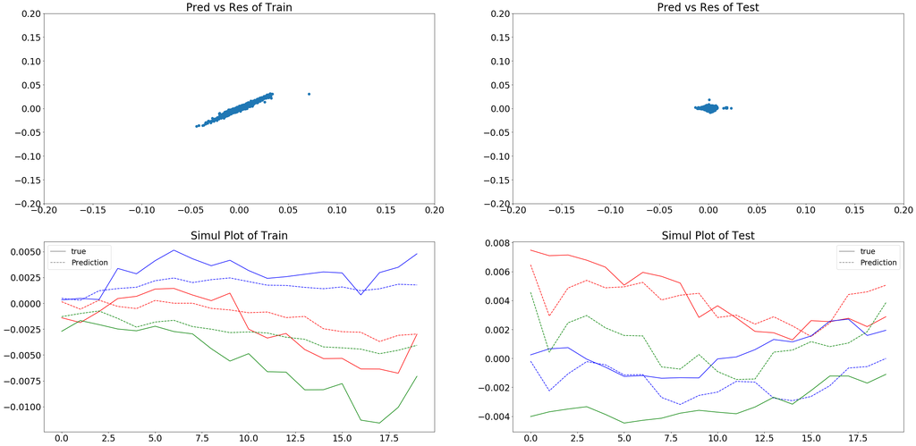

```python
directional_goodness(model_cnn_2inputs, x_test, y_test)
compare_top(model_cnn_2inputs, x_test, y_test)
plots(model_cnn_2inputs, x_test=x_test, x_train=x_train, y_test=y_test, y_train=y_train)
```

Expectations:

- CNN with additional information of industry affiliation can detect known patterns of stocks in the same category
- This leads to better predictions

Results:

- Didn´t help considerably to enhance prediction power
- could be the result of overfitting due to industry labels

Conclusion:

- Patterns in stocks seem to be to variable to be efficiently detected and don´t contribute to effective prediction power in our calculation regime

### Recurrent Neural Network with Gated Recurrent Units

#### advantages:

- optimized for time series predictions
- input length not fixed

#### disadvantages:

- trains considerably slowly

```python
model_gru,x_train,y_train,x_test,y_test = main_gru(returns, 100, 2000, variant='month')
print(model_gru.summary())
```

```
x-train shape: (1900, 100, 20)
y-train shape: (1900, 20)
x-test shape: (518, 100, 20)
y-test shape: (518, 20)
test shape: (618, 20)
9.968522394728129e-06
9.96852213575039e-06
0.002318443264812231
Model: "sequential_6"
_________________________________________________________________
Layer (type)                 Output Shape              Param #
=================================================================
gru_5 (GRU)                  (None, 100, 42)           7938
_________________________________________________________________
dropout_9 (Dropout)          (None, 100, 42)           0
_________________________________________________________________
gru_6 (GRU)                  (None, 42)                10710
_________________________________________________________________
dense_23 (Dense)             (None, 100)               4300
_________________________________________________________________
dense_24 (Dense)             (None, 20)                2020
=================================================================
Total params: 24,968
Trainable params: 24,968
Non-trainable params: 0
_________________________________________________________________
None
```

```
percentage of correctly predicted directions of returns: 0.556949806949807
Difference between mean return and return of calculated top 5: 0.00034326850447049693
(518, 20)
```

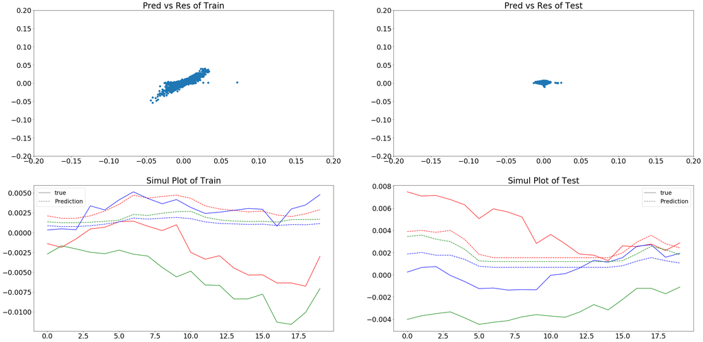

```python
directional_goodness(model_gru, x_test, y_test)
compare_top(model_gru, x_test, y_test)
plots(model_gru, x_test=x_test, x_train=x_train, y_test=y_test, y_train=y_train)
```

Expectations:

- RNN fits stock market data good, specialised on time series prediction
- GRU learns faster but less effective
- choice of hyperparameters essential

Results:

### Recurrent Neural Network with One-Hot Encoded Branch Info

#### advantages:

- network does not have to learn known correlations

#### disadvantages:

- more complicated data structure
- need to build non sequential network
  - one for adjusted close
  - one for industry sectors

```python
model_gru_2inputs,x_train,y_train,x_test,y_test = main_gru_2inputs(returns, 100, 2000, variant='month')
print(model_gru_2inputs.summary())
```

```
x-train shape: (1900, 100, 20)(1900, 7, 20)
y-train shape: (1900, 20)
x-test shape: (518, 100, 20)(518, 7, 20)
y-test shape: (518, 20)
test shape: (618, 20)
9.674283530021268e-06
9.674284228822216e-06
0.002330100629478693
Model: "model_12"
__________________________________________________________________________________________________
Layer (type)                    Output Shape         Param #     Connected to
==================================================================================================
input_7 (InputLayer)            (None, 100, 20)      0
__________________________________________________________________________________________________
gru_7 (GRU)                     (None, 100, 100)     36300       input_7[0][0]
__________________________________________________________________________________________________
input_8 (InputLayer)            (None, 7, 20)        0
__________________________________________________________________________________________________
dropout_10 (Dropout)            (None, 100, 100)     0           gru_7[0][0]
__________________________________________________________________________________________________
flatten_9 (Flatten)             (None, 140)          0           input_8[0][0]
__________________________________________________________________________________________________
gru_8 (GRU)                     (None, 100)          60300       dropout_10[0][0]
__________________________________________________________________________________________________
dense_25 (Dense)                (None, 100)          14100       flatten_9[0][0]
__________________________________________________________________________________________________
concatenate_4 (Concatenate)     (None, 200)          0           gru_8[0][0]
                                                                 dense_25[0][0]
__________________________________________________________________________________________________
dense_26 (Dense)                (None, 100)          20100       concatenate_4[0][0]
__________________________________________________________________________________________________
dense_27 (Dense)                (None, 20)           2020        dense_26[0][0]
==================================================================================================
Total params: 132,820
Trainable params: 132,820
Non-trainable params: 0
__________________________________________________________________________________________________
None
```

```
percentage of correctly predicted directions of returns: 0.5417953667953668
Difference between mean return and return of calculated top 5: 0.00045099988818302517
(518, 20)
```

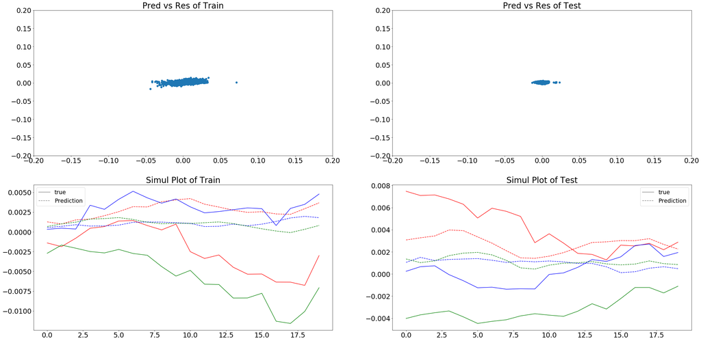

```python
directional_goodness(model_gru_2inputs, x_test, y_test)
compare_top(model_gru_2inputs, x_test, y_test)
plots(model_gru_2inputs, x_test=x_test, x_train=x_train, y_test=y_test, y_train=y_train)
```

Expectations:

- Additional Industry information adds underlying structure
- fits become better than regular RNN (GRU)

Results:

- Underfitting

## Discussion and Outlook

- Neural Networks don´t really do a good job on predicting stock markets
- Patterns are too variable to be recognised as patterns by machines
- time series prediction works ok
- Input Data Transformations can be optimized, so that maybe structure is recognizable
  - smoothing, space transformation, clustering, etc
- Neural Networks can be optimized
  - hyperparameters are of the essence with most NNs
  - input shape (time window, stock number)
  - number of different kinds of neurons, layers, etc.
  - activation functions
- More computational power could help
  - sometimes NNs have a "breakthrough" in learning curve after what seems like convergence
- ..